# Final Project

Final Project  
Data Science 1 with R (STAT 301-1)

Author

Allison Kane

Published

December 6, 2023

**Github Repo Link**

[Allison Kane Final Project Repo Link](https://github.com/stat301-1-2023-fall/final-project-1-akane2460.git)

## Data source

The data to be analyzed is information from seasons 1-14 of the US series of the reality TV show *Shark Tank*[^1], a show where entrepreneurs pitch their emerging businesses to a panel of investors called *sharks*. This dataset includes information about the entrepreneurs, their businesses, and their deals with the sharks.

## Research Questions

In investigating this data, I intend to find if there are differences between the investment and pitching trends of female and male entrepreneurs and sharks. Outside of reality TV, female entrepreneurs tend to face greater barriers and often have their businesses undervalued. Industries typically thought to be female-dominated or feminine are often less respected.

In this dataset, I specifically aim to investigate if (1) female entrepreneurs are represented as often as male entrepreneurs in the show, (2) if female entrepreneurs ask for similar amounts of investment, valuation, and equity in their businesses as male entrepreneurs, (3) female entrepreneurs receive investment as often as male entrepreneurs, (4) if that investment aligns with their initial demands (i.e. quality of investment), (5) which sharks invest in female entrepreneurs more often, and (6) if specific sharks undervalue businesses started by women compared to men. Additionally, I plan to investigate (7) which types of businesses attract more female entreprenurs, (8) if these businesses receive investment as often by investors, and (9) which sharks invest most often in these industries. Follow-up studies may be done to see how these trends change over time. Perhaps in the years the show has been on the air the treatment of female entrepreneurs has changed or the investment trends of sharks has changed. Additionally, I might conduct further study to see if a male partner improves female entrepreneur investment outcomes and if a female partner worsens male entrepreneur investment outcomes.

## Initial Analyses

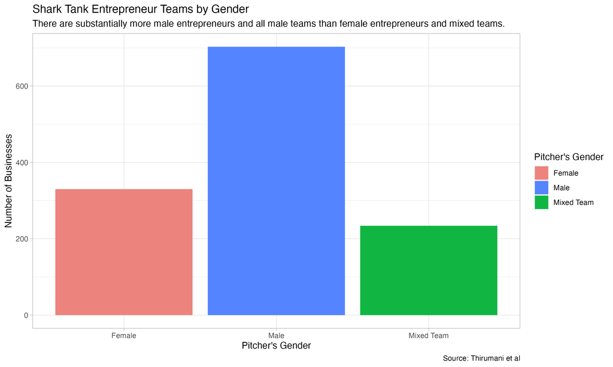

Gender Ratios Plot

In the plot above[^2], it is clear that female entrepreneurs and all female teams are underrepresented when compared to male entrepreneurs and all male teams. Mixed teams are underrepresented when compared to both. There seems to be some bias in the gender balance of the show, which is to be expected since female entrepreneurs tend to face more obstacles in building their businesses and are underrepresented in leadership positions.

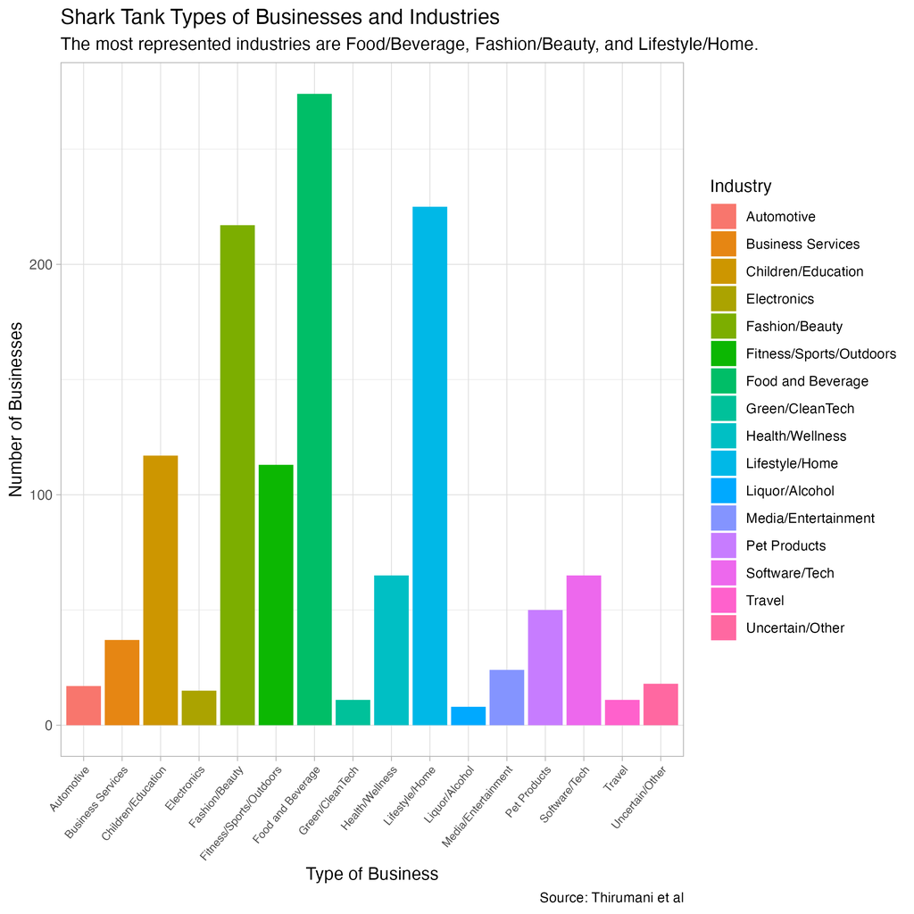

In the plot above[^3], it is seen that Food/Beverage, Fashion/Beauty, and Lifestyle/Home are represented the most. Some of these industries tend to be more associated with stereotypical “feminine” interests like Fashion and Beauty. Further investigation should be conducted to see if there is a bias for more female entrepreneurs to work in these industries.

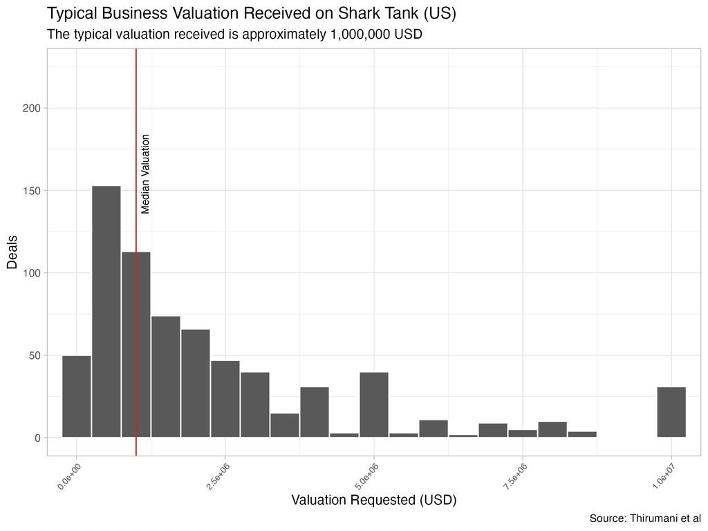

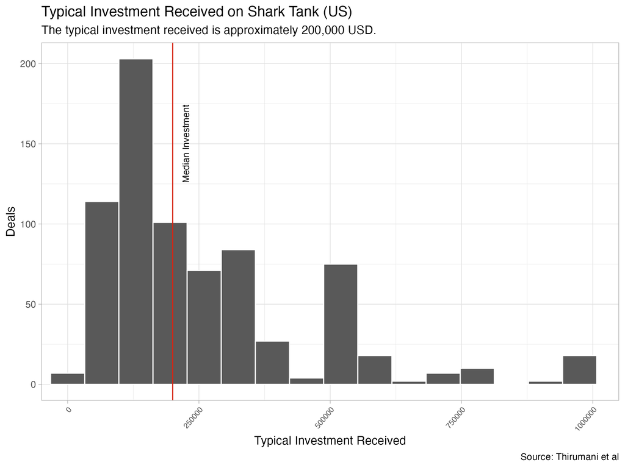

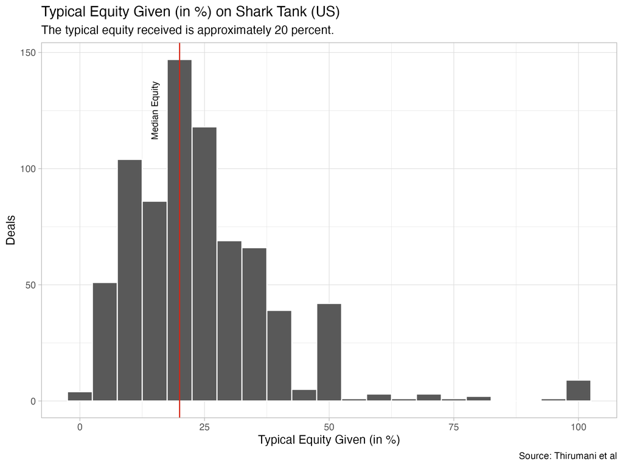

In the plot above[^6], it is seen that the typical equity received (for those that received deals) was approximately 20 percent, with a slight skew to the right. The lowest amount invested was 2 percent and the highest 100 percent (indicating that the shark bought the company outright). Further analysis will be conducted to determine how these amounts vary by gender.

Further analyses will be conducted to see how the details of each deal differ from what was originally requested and how that varies by gender. Further analysis will be conducted to investigate individual shark’s behavior and how they tend to treat male vs. female vs. mixed team entrepreneurs.

## Misc and Self-Assessment

There is still quite a bit to do in getting this project together. I have completed some univariate analyses general distributions of gender, types of businesses, and typical investment amounts and equities seen for each investment. I next plan to investigate the relationships between shark, the entrepreneur’s gender, their business, and quality of investment received. These will require bivariate and multivariate analyses. I will also conduct further analyses on perhaps how these trends have changed over time. Additional data cleaning might be required although I do not anticipate needing it at this time.

There are specific issues within the dataset for seasons 11-14 which I am unsure of how to resolve. Each shark is listed as `NA` for their attendance. It is clear that this is an issue of missing data, not a replacement for whether or not they were present at the pitch (as there are pitches where sharks have invested that their attendance is listed as `NA` for). Moving forward, I plan to not use these seasons as a measure of a shark’s typical behavior (i.e. I will exclude seasons 11-14 for answering questions like “How often does Barbara Corcoran invest in businesses led by female entrepreneurs?”).

I am also unsure of how to handle instances of multiple investors. For the time being, I am treating instances of multiple investors to be the same as an individual investment (i.e. If Mark Cuban invested 700,000 and Barbara Corcoran invested 500,000 in the same business, I will be treating those as *seperate* investment occurrences).

Some variables that have significant missingness issues like `pitcher_city`, `pitcher_state`, `company_website` are removed from the dataset, as they are not relevant to the questions presented

## Footnotes

[^1]: [Thirumani, S., Rehman, A.U., and Molagoda, J., 2023, Shark Tank US dataset, https://www.kaggle.com/datasets/thirumani/shark-tank-us-dataset](https://www.kaggle.com/datasets/thirumani/shark-tank-us-dataset)
[^2]: Relates to research question number 1
[^3]: Relates to research question number 7
[^4]: Relates to research question number 2 and 4
[^5]: Relates to research question number 2 and 4
[^6]: Relates to research question number 2 and 4